# Analysis of Prosper Loans

Bernardo Romero

2019-01-27

[figure not shown]

Borrowers get fixed-rate loans between US$ 2,000 and US$ 40,000 in fixed terms of 3 or 5 years. The money enters their bank accounts after only a few days of accepting a loan offer, and prepayments are not penalized.

Peer-to-peer loans refers to the lack of a financial intermediary in the operation. Instead, a lender and a borrower meet at a marketplace (in this case Prosper) and agree to the loan terms. This model was very revolutionary in 2005 when the company was created, and has attracted several competitors. Borrowers usually can find loans they could not find in the financial sector, and investors have a high-return in a relatively low-risk investment mechanism.

The dataset was provided directly by Udacity and can be obtained [here](https://www.google.com/url?q=https://s3.amazonaws.com/udacity-hosted-downloads/ud651/prosperLoanData.csv&sa=D&ust=1544380084735000). It has 81 variables, which obliges to focus this analysis on only a few of them. A data dictionary can be read [here](https://docs.google.com/spreadsheets/d/1gDyi_L4UvIrLTEC6Wri5nbaMmkGmLQBk-Yx3z0XDEtI/edit#gid=0).

**Some inicial questions that pop-up immediately are**:

- What are some characteristics of prosper loans? (term, amounts, default rates)
- What are characteristics of borrowers/lenders in the platform? (geography, demographics, employment)
- What variables are related to each other?
- What factors can lead to defaulting a loan?

We will see if we can answer some of these questions by performing an Exploratory Data Analysis in three phases: 1. Univariate Analysis 2. Bivariate Analysis 3. Multivariate Analysis

# Univariate Plots Section

In this first phase, we will get acquainted with the dataset, explore some of its variables independently and identify some interesting aspects that can further guide the analysis. This process needs to be done hand-in-hand with the data dictionary to be sure that we are interpreting correctly the different variables.

## Counting the number of variables and observations

```
## [1] 113937     77
```

A listing is a unique observation, which depicts one borrowing process from the application until its closing. A listing is closed when it’s status is either cancelled, completed, charged off or defaulted. Defaulted listings are those that have payments due for over 120 days, but that are still in the recovery process. Charged-off listings are defaulted listings that have been already written-off and removed from accounting (accounts receivable).

## Diverse counts for categorical variables

| LoanStatus | n |
| --- | --- |
| Current | 56576 |
| Completed | 38074 |
| Chargedoff | 11992 |
| Defaulted | 5018 |
| Past Due (1-15 days) | 806 |
| Past Due (31-60 days) | 363 |
| Past Due (61-90 days) | 313 |
| Past Due (91-120 days) | 304 |
| Past Due (16-30 days) | 265 |
| FinalPaymentInProgress | 205 |

[output cut: 2 more lines]

| Term | n |
| --- | --- |
| 36 | 87778 |
| 60 | 24545 |
| 12 | 1614 |

| ProsperRating..numeric. | n |
| --- | --- |
| 1 | 6935 |
| 2 | 9795 |
| 3 | 14274 |
| 4 | 18345 |
| 5 | 15581 |
| 6 | 14551 |
| 7 | 5372 |
| NA | 29084 |

| ProsperScore | n |
| --- | --- |
| 1 | 992 |
| 2 | 5766 |
| 3 | 7642 |
| 4 | 12595 |
| 5 | 9813 |
| 6 | 12278 |
| 7 | 10597 |
| 8 | 12053 |
| 9 | 6911 |
| 10 | 4750 |

[output cut: 2 more lines]

**Notes**: Most of the listings have the status “current”, which is a good indication of a growing business. Most have a term of three years. Three or five years seem like the two main options for borrowing with Prosper. “Prosper Rating” (7 = best) is allocated considering credit scores to every listing by creation time, whereas a “Prosper Score” is a custom score (1 = worst, 10 = best) based on historical Prosper Data.

## Range of dates for creation of listings in the dataset

```
## [1] "2005-11-09 20:44:28 CET" "2014-03-10 12:20:53 CET"
```

## Distribution of listings by status

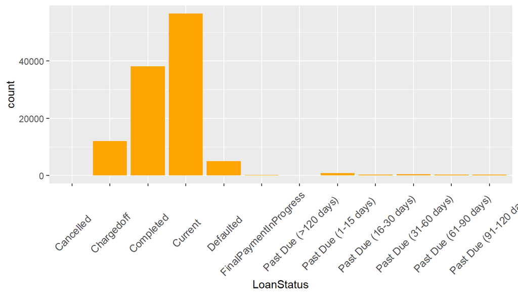

**Notes**: Most of the listings have “current” as status (roughly 55,000), followed by “completed” (at dataset generation). The number of “past due” listings seems very low. However, roughly 12,000 charged-off loans is a considerable amount of listings that are deemed not-recoverable.

## How much do people borrow in Prosper?

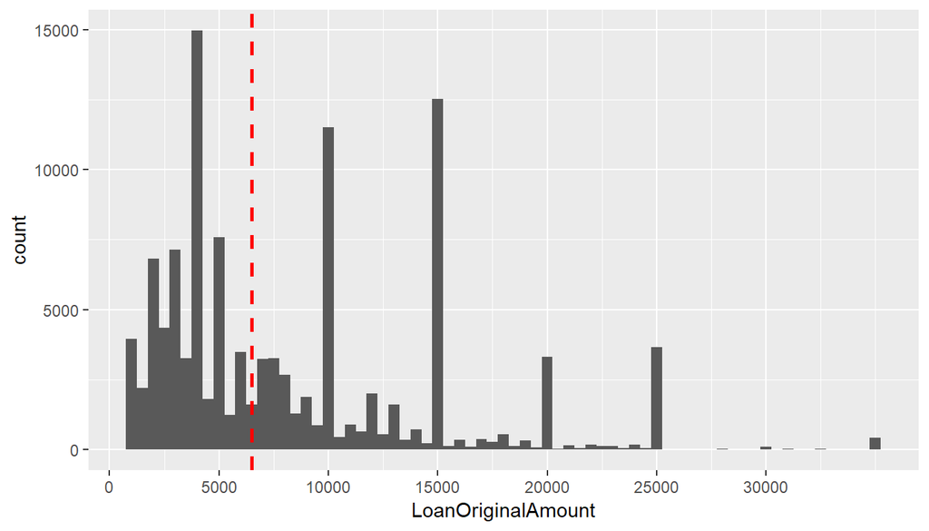

## Evaluating the “past due” status of loans

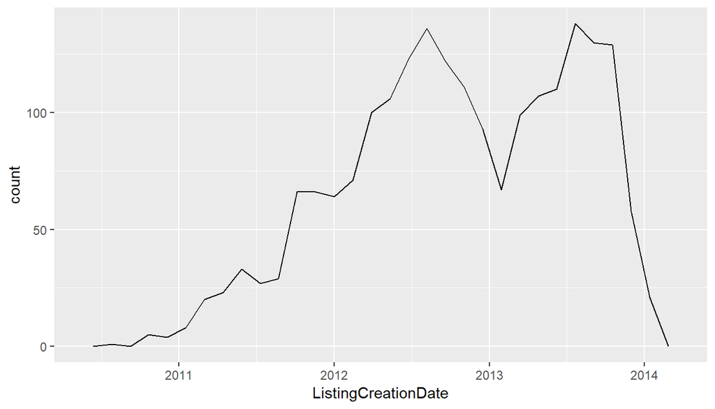

**Notes**: It seems the past_due status is not an old function, and that the seemingly low proportion of loans with “past due” status is accurate.

## Distribution of listing by Status, facet by Term

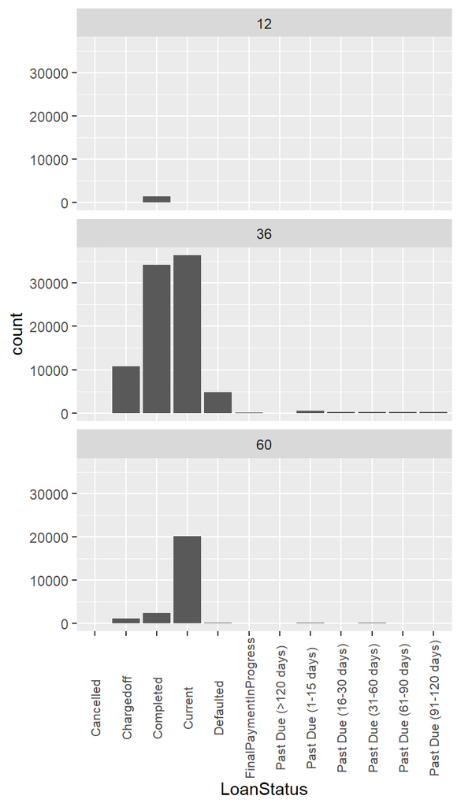

**Notes**: We see that 12-month loans existed in the past and there are no current loans with that term. Most loans have a term of 36 months, but the ratio of current vs completed loans is larger for 60 month loans. This could mean that demand for longer loans grows faster, or that the company and/or investors prefer longer terms.

## Distribution of listings by Prosper Score

The mean is displayed with the red dashed line

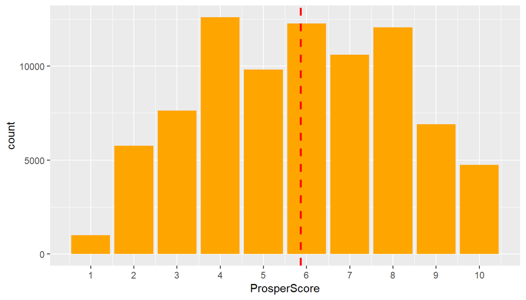

**Notes**: The Prosper Score rates 10 as lowest risk and 1 as highest. This distribution suggests a rather good risk distribution of the listings, with most of them displaying a score of between 4 and 8.

I subsetted the data to remove values with score 11, which is a value not described in the data dictionary, and which might correspond to listings before 2009 when the Prosper Score was introduced.

## Distribution by Loan Category

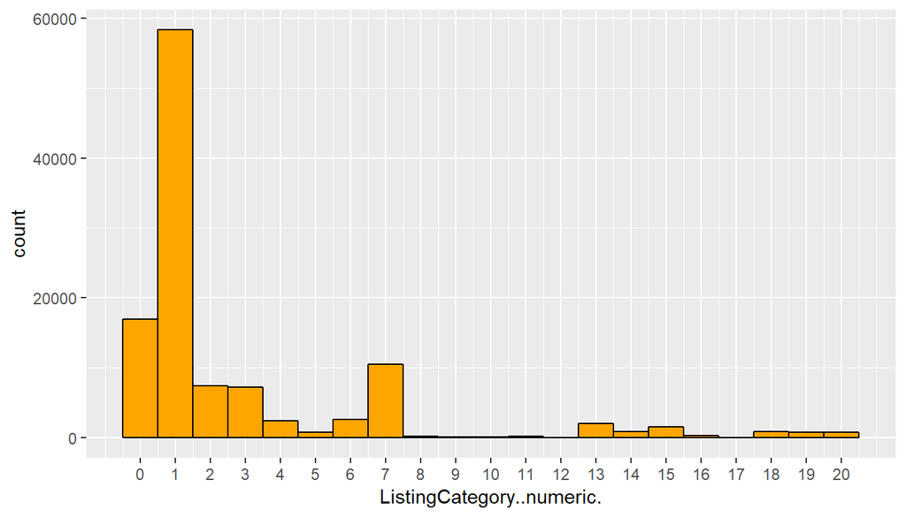

**Notes**: The vast majority of the listings fall under the category “1”, which according to the data dictionary corresponds to Debt Consolidation. This is a category that the borrower chooses when applying for a loan. “0” means the information is not available, and “7” corresponds to “other”, completing the three most frequent categories. “2” and “3” correspond to Home Improvement and Business, respectively.

## Value of loans by Borrower’s state

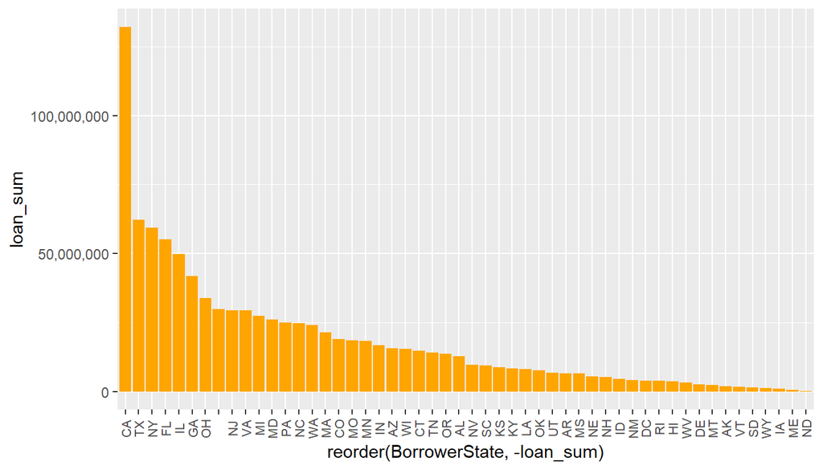

**Notes**: California is Prosper Loans largest market, followed distantly by Texas, New York, Florida and Illinois. An Internet search shows that these States, in the same exact order, are the U.S. largest by population. Prosper has offices in San Francisco (CA), and Phoenix (TX). Further expansion into the next three largest states could make sense in the expansion strategy of the company.

## Distribution by APR and Interest Rate

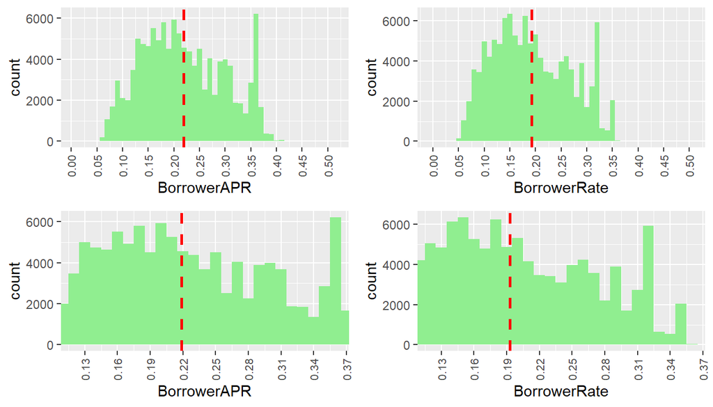

These two histograms indicate that APR follows a very similar distribution as the interest rate, meaning that the fees and other costs are distributed evenly.I will focus on APR for further analysis, because it is a better description of the actual price a borrower pays for the loan received.

We see a marked peak around a rate of 35%, although the bulk of the listings have a rate of between 12% and 25%. This seems accurate, given Prosper’s claim on its website:

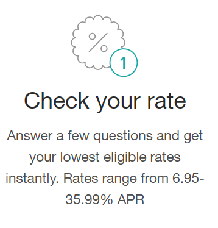

From prosper.com

# Distribution by monthly payments

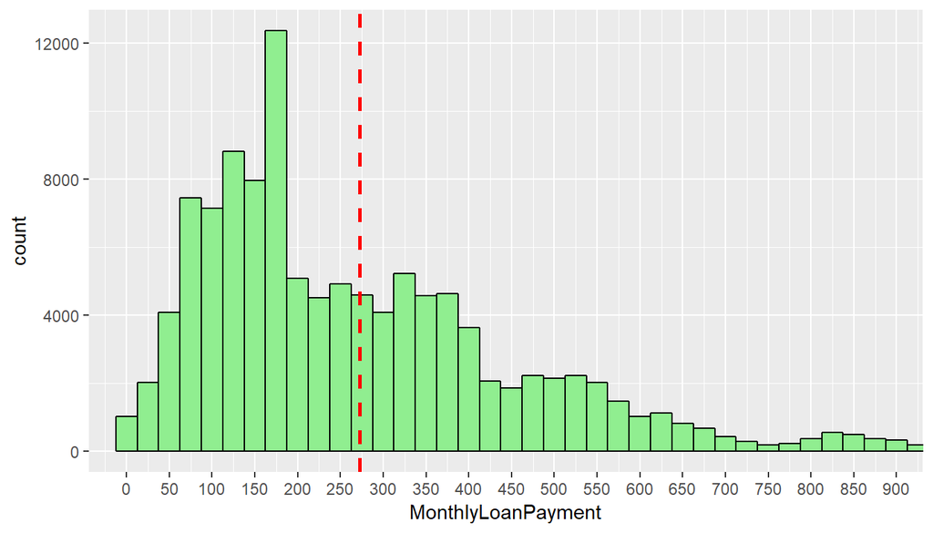

**Notes**: Most Borrowers at Prosper pay between US$ 50 and uS$ 400 per month for their loans, and the mean is around US$ 275 Let’s see a five number summary for this distribution in the next chart.

# Explore descriptive statistics for monthly payments by Prosper Score

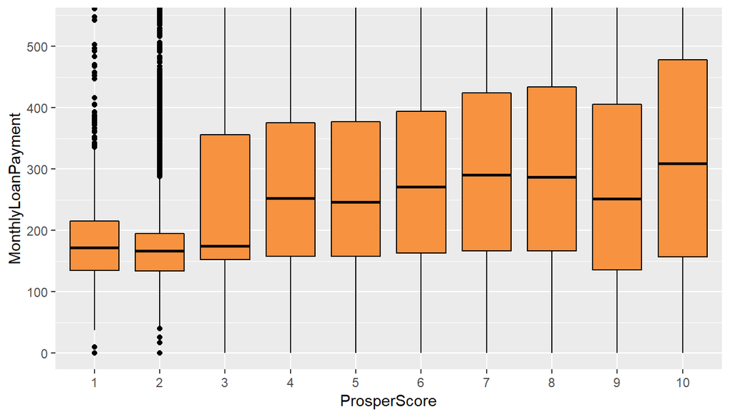

# Comparison of Loans Originated by year

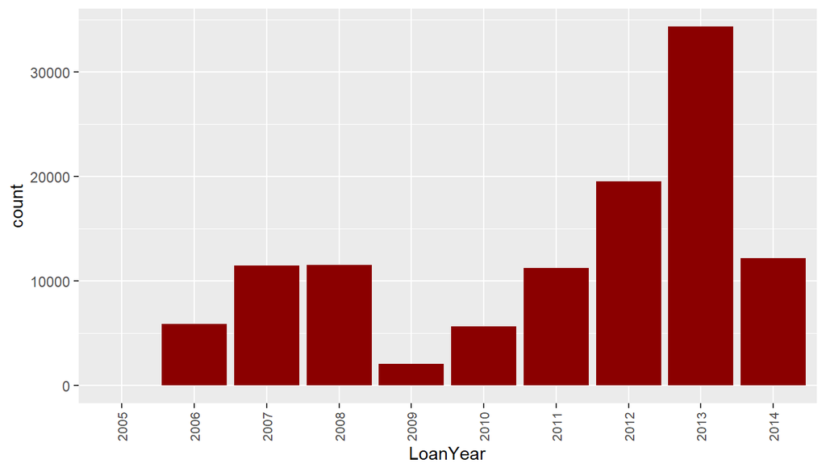

**Notes**: It is immediately clear the effect that the 2008 financial crisis and the subsequent recession had in the number of loans initiated by Prosper. The number of loans grew again in 2011 and did more significantly so into 2013. The data set is from the first half of 2014, which explains the lower number of credits displayed for that year.

# Number of Investors

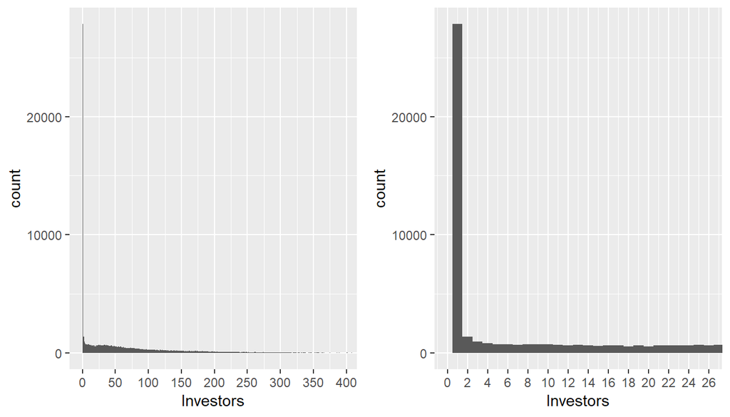

# Listings by the number of Borrowers’ Current Credit Lines

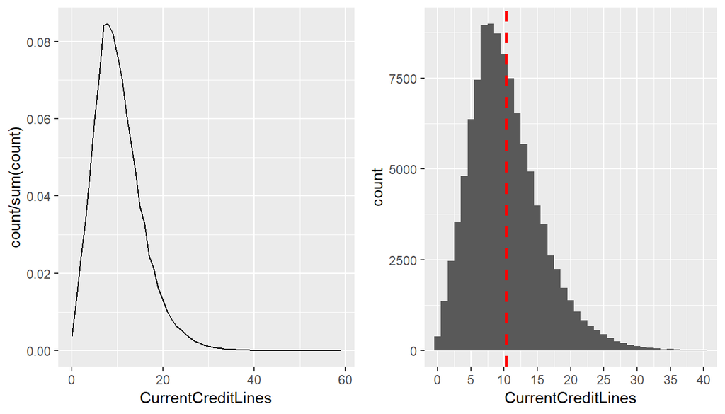

**Notes**: This chart indicates that most borrowers have several credit lines opened by the time they apply for a credit at Prosper. Most borrowers will have between 5 and 15 open credit lines by application time, with a mean value of 10.

# Univariate Analysis

This completes the Univariate Analysis of the dataset. Having over 80 variables, much more exploration could be performed on this dataset, but we will limit it here following the projects rubric established by Udacity.

#### What is/are the main feature(s) of interest in your dataset?

- Data about the listing itself: status, estimated returns, category, score, etc.
- Data about the borrower: employment status, state and sociodemographic information.
- Data about the credit record of the borrower
- Data about the loan: different from the listing. Amount, payments, amount outstanding, number of investors etc.

#### What other features in the dataset do you think will help support your investigation into your feature(s) of interest?

I am interested in the evolution of the peer-to-peer lending concept. Being a very innovative idea, I want to have a clearer idea of whether Prosper’s business case is strong and whether the situation is risky for the company in terms of default rates.

#### Did you create any new variables from existing variables in the dataset?

I created the LoanYear variable to plot the evolution of number loans by year

#### Of the features you investigated, were there any unusual distributions? Did you perform any operations on the data to tidy, adjust, or change the form of the data? If so, why did you do this?

In most histograms I adjusted the bins to reflect the actual units of analysis. With so many data points I also used jitter and alpha settings for better visualization. I displayed reference mean values.

I expected the number of investors per loan to be much larger in average, but it is clear that one investor is the norm for Prosper loans. Most findings correspond to what could be expected: The largest number of loans go the largest states, the APR is larger than the interest rates and the effects of the financial crisis are visible.

# Bivariate Plots Section

In this section, we continue with the data exploration by comparing two variables with each other, looking for interesting relationships.

## Comparing Borrower APR with Lender yield

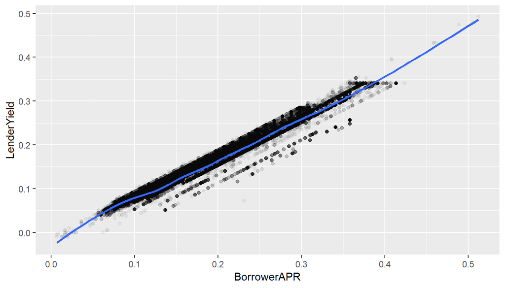

**Notes**: We start by checking what should be a strong correlated pair of variables: the Borrower APR and the Investor’s yield. The positive correlation is evident in the plot, and it is also clear the the APR doesn’t march directly the yield rate. The difference represents the companies fees, which is where the core of Prosper’s business is.

# Evolution of loans by employment status

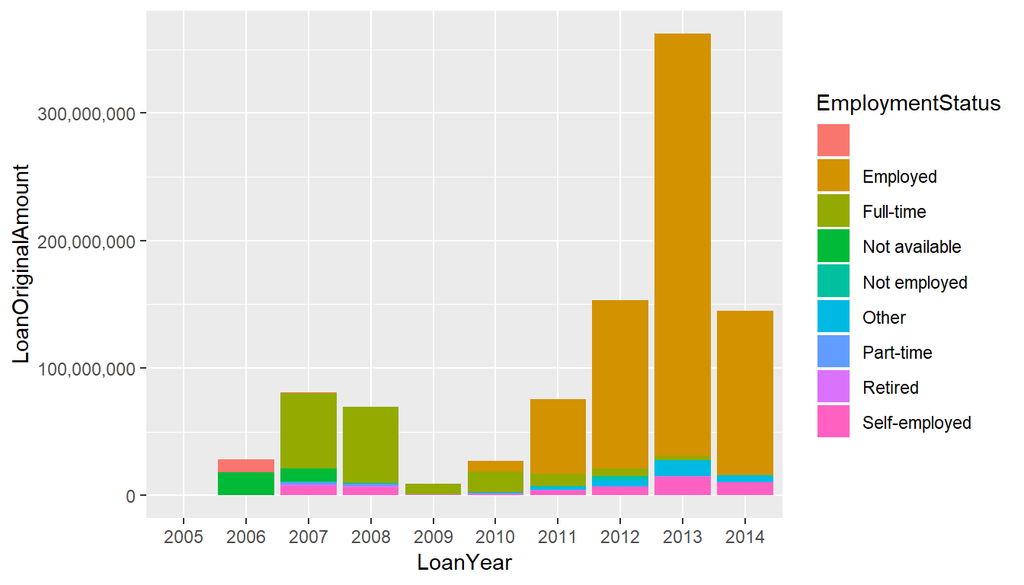

**Notes**: We can clearly see here that Prosper almost only intermediates loans for employed borrowers. Only an additional fraction of the loans go to self-employed borrowers.

# Monthly payments by Monthly Income

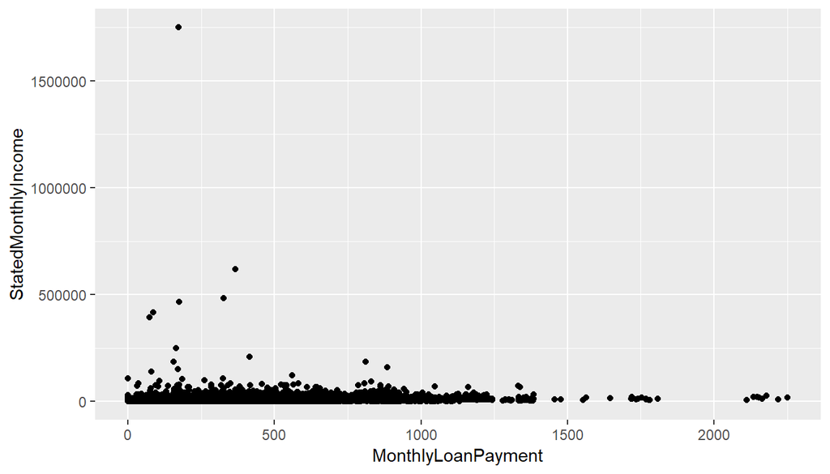

**Notes**: One listing has a borrower’s stated monthly income of around 2 Million, which is an outlier that I will consider a data entry error. Someone earning over 20 million US per year is not likely the target customer of Prosper loans. The next scatter plot removes outliers and allows for a better understanding of this relationship.

# Modified monthly payments by monthly income

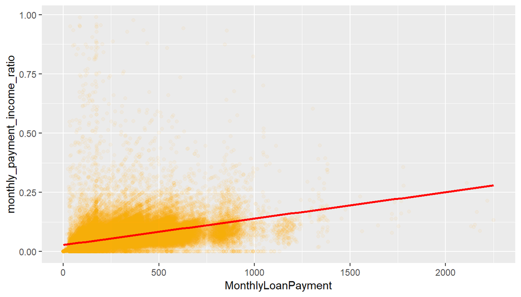

**Notes**: This scatter plot, allows to have a better idea of the relationship between a borrower’s income and their monthly payments. For most borrowers, their monthly payments take under 25% of their monthly income. There seams to be a weak positive relationship between both variables, which we will next calculate.

I only consider those borrowers whose ratio falls below 100% of their monthly income. Everything else I assume to be unrealistic information as no lender will invest when the borrower states a monthly income that is less of their monthly payment.

# Calculate correlation

```
##
##  Pearson's product-moment correlation
##
## data:  df$StatedMonthlyIncome and df$MonthlyLoanPayment
## t = 67.716, df = 113760, p-value < 2.2e-16
## alternative hypothesis: true correlation is not equal to 0
## 95 percent confidence interval:
##  0.1912436 0.2024150
## sample estimates:
##       cor
## 0.1968357
```

**Notes**: The calculated correlation of 0.197 is a weak positive correlation between a borrower’s monthly income and monthly payments.

# Change in loan status by year

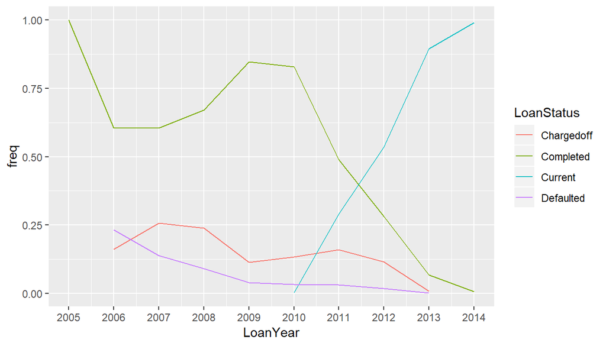

**Notes**: What is most interesting in the previous chart, are the high but falling default and charged-off rates. The falling tendency has to do with the fact that newer credits should have lower default rates, but even for credits above the usual lending duration of 3-5 years, the rate appears falling.

Almost a quarter of all loans in 2007 and 2008 were charged-off, and in the following three years the rate remained at around 12.5%. This is why financial services companies invest significantly in debt recovery at the early stages when a borrower starts to fall behind in payments. A past due payment defaults after four only four months, impacting very negatively the overall cost and risk of the company.

Given that peer-to-peer lending was introduced recently to the market and that it is a rather unknown mechanism by lenders and borrowers, it can naturally be riskier than traditional financial services.

I will focus on these four loan status for further analysis.

## Loan Status by APR

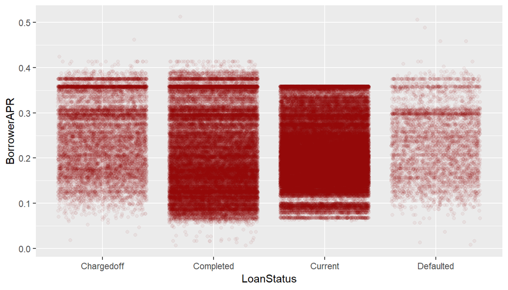

**Notes**: There doesn’t seem to exist much difference in the Borrower APR distribution across Loan Statuses. However, it is interesting to see that for defaulted and charged-off loans, the concentration is towards higher rates. We will explore this further in the next chart.

## Distribution of loan status, facetted by Borrower APR

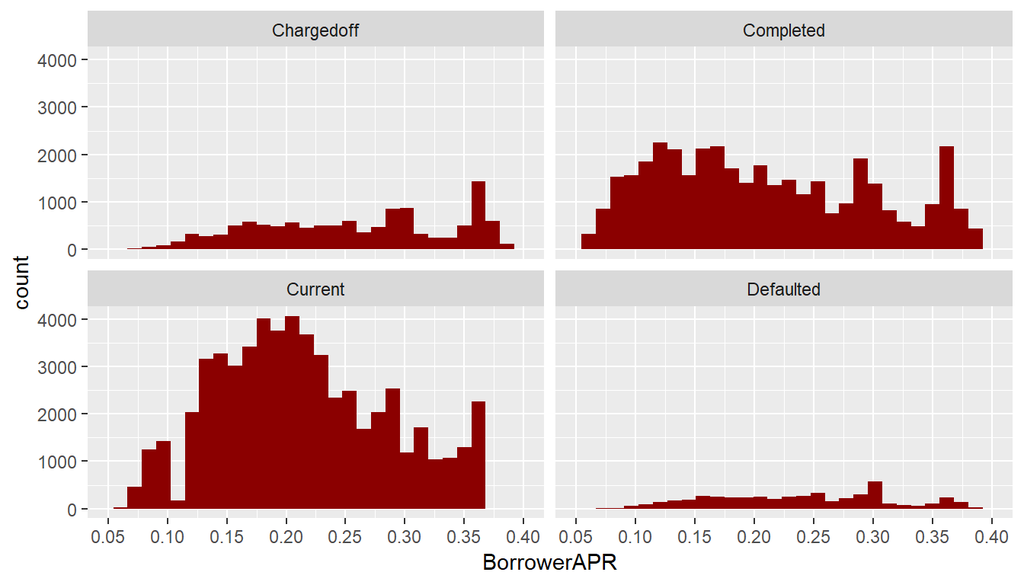

**Notes**: We can now clearly see the peaks in Borrower APR for charged-off at 35% and defaulted at 30%. Borrowers that defaulted on their payments had usually higher APR.

## Defaults by Prosper Score

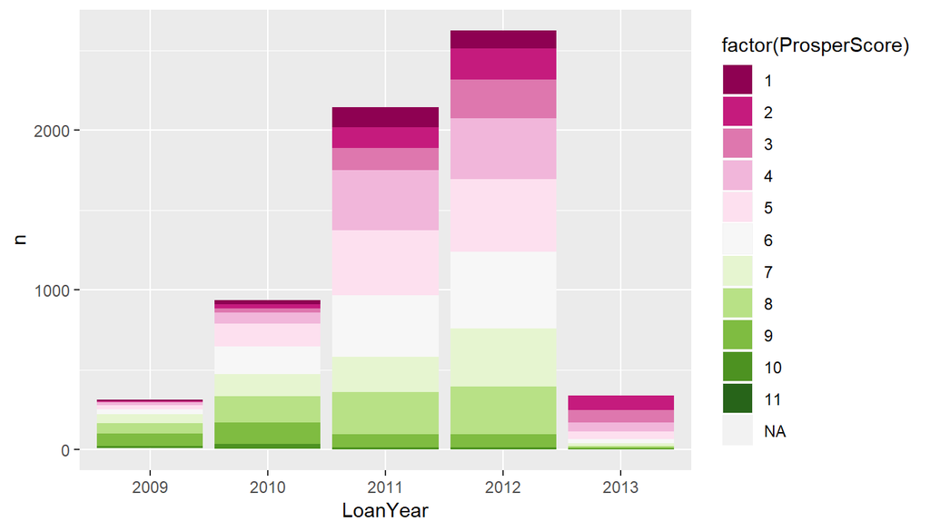

**Notes**: The chart shows how loans that have been charged off or are in default, had most of its ratings in the range 1-6, the most risky half of the scale. The proportions don’t change much from year to year. Prosper is a platform where probably customers come after being denied credit by banks, probably younger people with less good credit scores prefer this unconventional lending mechanisms, which raises the overall risk of the operation. Prosper has taken a rather open (and probably riskier) approach to loan mediation.

## Default ratio by state

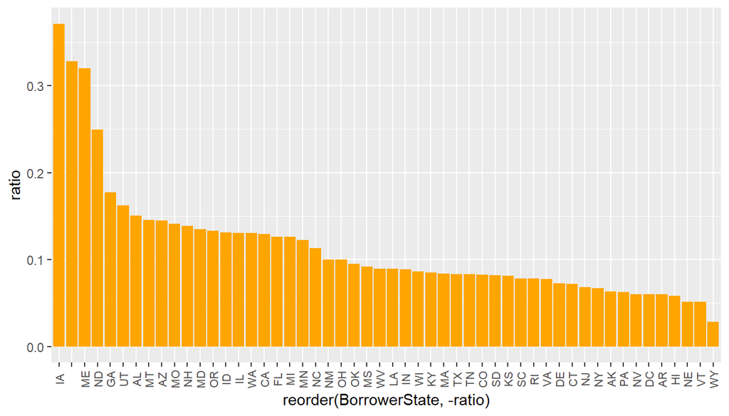

**Notes**: this visualization orders U.S. states according to their default ratio. The default ratio I use includes loans with statuses Defaulted and Charged-off. They both relate to loans that have not been paid for over 120 days, with the difference that charged-off have already been even written-off from the company’s accounting. The largest states that we saw in the first analysis by state, don’t appear as those with the highest default ratios. It would be interesting for further research to investigate the relationship of this ratios with poverty or unemployment rates by state.

## Impact of home owning to default rates

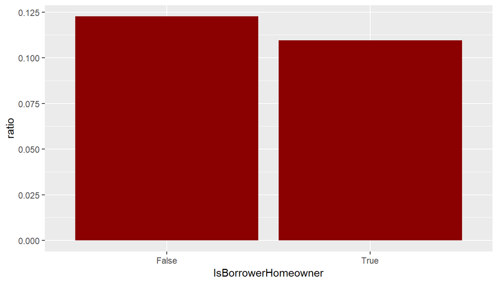

**Notes**: the default ratio for non-home owners is slightly larger as the one for home owners.

## Relationship between Debt to Income Ratio and Amount Delinquent

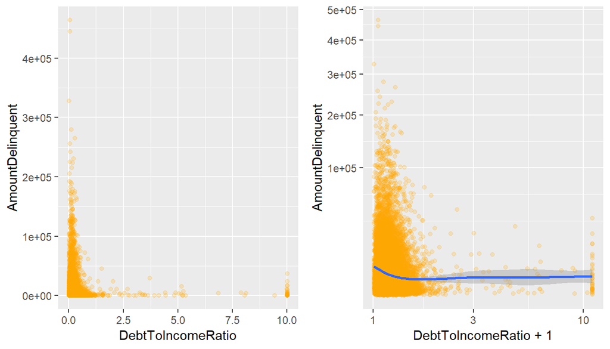

```
##
##  Pearson's product-moment correlation
##
## data:  loans$DebtToIncomeRatio and loans$AmountDelinquent
## t = -6.0705, df = 97903, p-value = 1.28e-09
## alternative hypothesis: true correlation is not equal to 0
## 95 percent confidence interval:
##  -0.02565829 -0.01313516
## sample estimates:
##         cor
## -0.01939749
```

## Relationship between Debt to Income Ratio and the monthly payment to income ratio

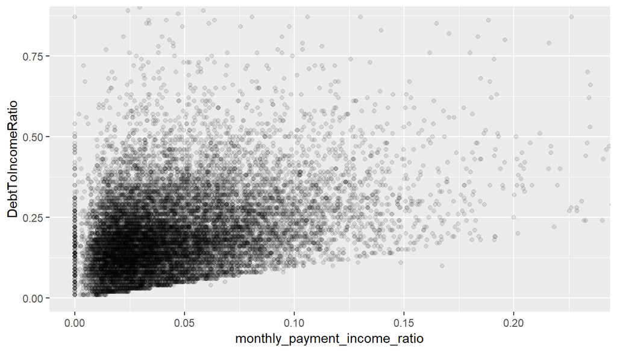

**Calculating the correlation between both variables**

```
##
##  Pearson's product-moment correlation
##
## data:  loans$monthly_payment_income_ratio and loans$DebtToIncomeRatio
## t = 99.508, df = 105380, p-value < 2.2e-16
## alternative hypothesis: true correlation is not equal to 0
## 95 percent confidence interval:
##  0.2875428 0.2985809
## sample estimates:
##       cor
## 0.2930716
```

**Notes**: We find a moderate correlation (0.29) between the debt/income ratio of a borrower and their monthly payment/income ratio. This roughly means that borrowers who pay more debt from their income, are also more indebted.

## Plotting bivariate variables *en masse*

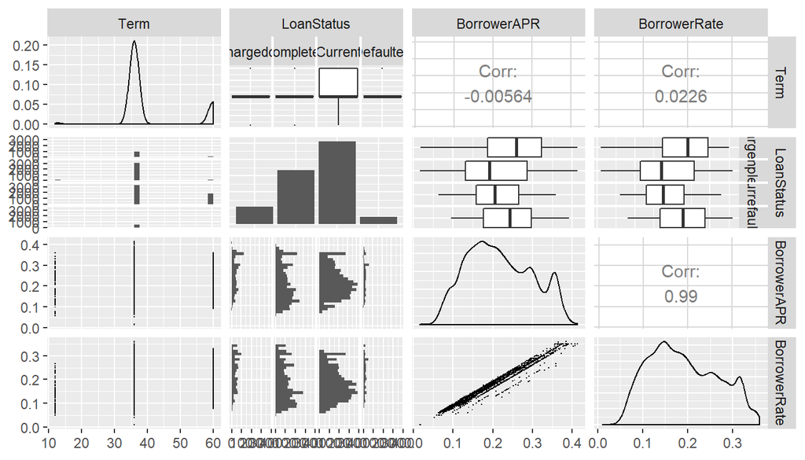

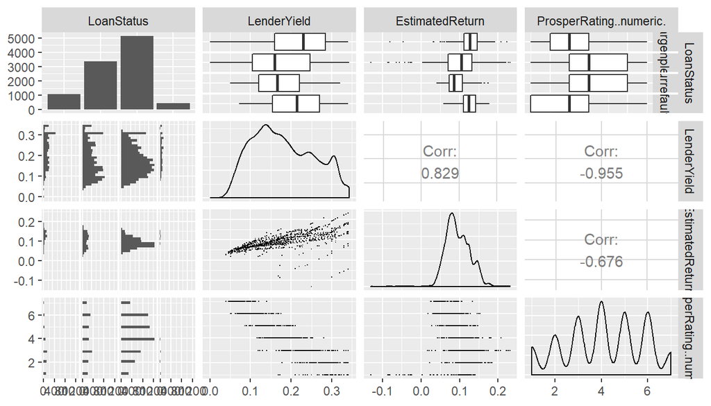

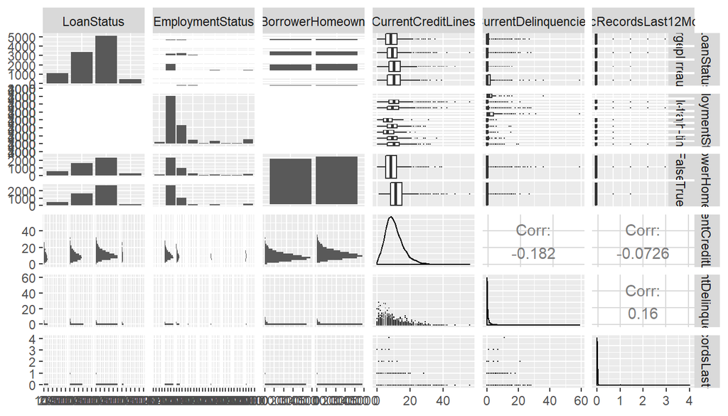

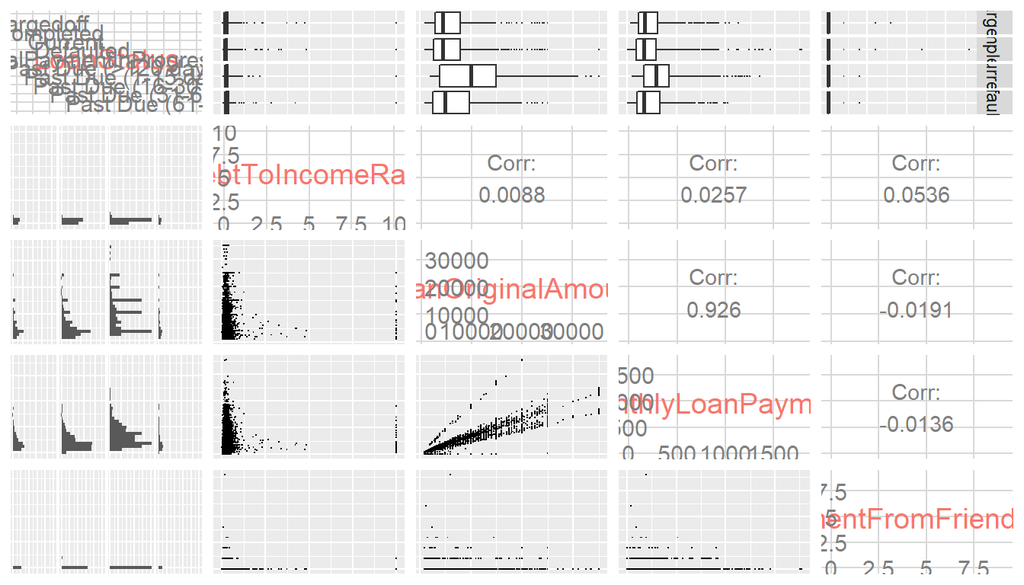

**Notes**: Exploring many relationships at once with these ggpairs charts, we see a lot of confirmation from the previous analysis, and new questions arise. For example, what factors affect lenders’ return? For example, we can see here a very strong correlation between the lender yield and the Prosper Rating. What credit rating score is better to predict default rates? What credit amount range has a stronger correlation with defaulted loans? The possibilities for further exploration are still large.